# Risk Factor Analysis

## Outcome Variable

**Outcome Variable:** stunted

## Predictor Variables

**Intervention Variable:** mage

**Adjustment Set:**

- arm
- meducyrs
- feducyrs
- W_mhtcm
- single
- delta_meducyrs
- delta_feducyrs
- delta_W_mhtcm
- delta_single

## Stratifying Variables

The analysis was stratified on these variable(s):

- agecat
- studyid
- country

## Data Summary

| agecat | studyid | country | mage | stunted | n_cell | n |
| --- | --- | --- | --- | --- | --- | --- |
| Birth | ki0047075b-MAL-ED | BANGLADESH | <20 | 0 | 27 | 257 |
| Birth | ki0047075b-MAL-ED | BANGLADESH | <20 | 1 | 9 | 257 |
| Birth | ki0047075b-MAL-ED | BANGLADESH | [20-25) | 0 | 70 | 257 |
| Birth | ki0047075b-MAL-ED | BANGLADESH | [20-25) | 1 | 14 | 257 |
| Birth | ki0047075b-MAL-ED | BANGLADESH | [25-30) | 0 | 77 | 257 |
| Birth | ki0047075b-MAL-ED | BANGLADESH | [25-30) | 1 | 15 | 257 |
| Birth | ki0047075b-MAL-ED | BANGLADESH | >=30 | 0 | 36 | 257 |
| Birth | ki0047075b-MAL-ED | BANGLADESH | >=30 | 1 | 9 | 257 |
| 6 months | ki0047075b-MAL-ED | BANGLADESH | <20 | 0 | 29 | 241 |
| 6 months | ki0047075b-MAL-ED | BANGLADESH | <20 | 1 | 6 | 241 |
| 6 months | ki0047075b-MAL-ED | BANGLADESH | [20-25) | 0 | 59 | 241 |
| 6 months | ki0047075b-MAL-ED | BANGLADESH | [20-25) | 1 | 19 | 241 |
| 6 months | ki0047075b-MAL-ED | BANGLADESH | [25-30) | 0 | 77 | 241 |
| 6 months | ki0047075b-MAL-ED | BANGLADESH | [25-30) | 1 | 10 | 241 |
| 6 months | ki0047075b-MAL-ED | BANGLADESH | >=30 | 0 | 31 | 241 |
| 6 months | ki0047075b-MAL-ED | BANGLADESH | >=30 | 1 | 10 | 241 |
| 24 months | ki0047075b-MAL-ED | BANGLADESH | <20 | 0 | 13 | 212 |
| 24 months | ki0047075b-MAL-ED | BANGLADESH | <20 | 1 | 16 | 212 |
| 24 months | ki0047075b-MAL-ED | BANGLADESH | [20-25) | 0 | 36 | 212 |
| 24 months | ki0047075b-MAL-ED | BANGLADESH | [20-25) | 1 | 28 | 212 |
| 24 months | ki0047075b-MAL-ED | BANGLADESH | [25-30) | 0 | 48 | 212 |
| 24 months | ki0047075b-MAL-ED | BANGLADESH | [25-30) | 1 | 34 | 212 |
| 24 months | ki0047075b-MAL-ED | BANGLADESH | >=30 | 0 | 17 | 212 |
| 24 months | ki0047075b-MAL-ED | BANGLADESH | >=30 | 1 | 20 | 212 |
| Birth | ki0047075b-MAL-ED | BRAZIL | <20 | 0 | 32 | 191 |
| Birth | ki0047075b-MAL-ED | BRAZIL | <20 | 1 | 2 | 191 |
| Birth | ki0047075b-MAL-ED | BRAZIL | [20-25) | 0 | 56 | 191 |
| Birth | ki0047075b-MAL-ED | BRAZIL | [20-25) | 1 | 7 | 191 |
| Birth | ki0047075b-MAL-ED | BRAZIL | [25-30) | 0 | 45 | 191 |
| Birth | ki0047075b-MAL-ED | BRAZIL | [25-30) | 1 | 9 | 191 |

[output cut: 508 more lines]

The following strata were considered:

- agecat: 24 months, studyid: ki0047075b-MAL-ED, country: BANGLADESH
- agecat: 24 months, studyid: ki0047075b-MAL-ED, country: BRAZIL
- agecat: 24 months, studyid: ki0047075b-MAL-ED, country: INDIA
- agecat: 24 months, studyid: ki0047075b-MAL-ED, country: NEPAL
- agecat: 24 months, studyid: ki0047075b-MAL-ED, country: PERU
- agecat: 24 months, studyid: ki0047075b-MAL-ED, country: SOUTH AFRICA
- agecat: 24 months, studyid: ki0047075b-MAL-ED, country: TANZANIA, UNITED REPUBLIC OF
- agecat: 24 months, studyid: ki1000108-CMC-V-BCS-2002, country: INDIA
- agecat: 24 months, studyid: ki1000108-IRC, country: INDIA
- agecat: 24 months, studyid: ki1017093-NIH-Birth, country: BANGLADESH
- agecat: 24 months, studyid: ki1017093b-PROVIDE, country: BANGLADESH
- agecat: 24 months, studyid: ki1017093c-NIH-Crypto, country: BANGLADESH
- agecat: 24 months, studyid: ki1066203-TanzaniaChild2, country: TANZANIA, UNITED REPUBLIC OF
- agecat: 24 months, studyid: ki1101329-Keneba, country: GAMBIA
- agecat: 24 months, studyid: ki1113344-GMS-Nepal, country: NEPAL
- agecat: 24 months, studyid: ki1119695-PROBIT, country: BELARUS
- agecat: 24 months, studyid: ki1126311-ZVITAMBO, country: ZIMBABWE
- agecat: 24 months, studyid: ki1135781-COHORTS, country: GUATEMALA
- agecat: 24 months, studyid: ki1135781-COHORTS, country: INDIA
- agecat: 24 months, studyid: ki1135781-COHORTS, country: PHILIPPINES
- agecat: 24 months, studyid: ki1148112-LCNI-5, country: MALAWI
- agecat: 24 months, studyid: kiGH5241-JiVitA-3, country: BANGLADESH
- agecat: 6 months, studyid: ki0047075b-MAL-ED, country: BANGLADESH
- agecat: 6 months, studyid: ki0047075b-MAL-ED, country: BRAZIL
- agecat: 6 months, studyid: ki0047075b-MAL-ED, country: INDIA
- agecat: 6 months, studyid: ki0047075b-MAL-ED, country: NEPAL
- agecat: 6 months, studyid: ki0047075b-MAL-ED, country: PERU
- agecat: 6 months, studyid: ki0047075b-MAL-ED, country: SOUTH AFRICA
- agecat: 6 months, studyid: ki0047075b-MAL-ED, country: TANZANIA, UNITED REPUBLIC OF
- agecat: 6 months, studyid: ki1000108-CMC-V-BCS-2002, country: INDIA
- agecat: 6 months, studyid: ki1000108-IRC, country: INDIA
- agecat: 6 months, studyid: ki1000109-EE, country: PAKISTAN
- agecat: 6 months, studyid: ki1000304b-SAS-CompFeed, country: INDIA
- agecat: 6 months, studyid: ki1000304b-SAS-FoodSuppl, country: INDIA
- agecat: 6 months, studyid: ki1017093-NIH-Birth, country: BANGLADESH
- agecat: 6 months, studyid: ki1017093b-PROVIDE, country: BANGLADESH
- agecat: 6 months, studyid: ki1017093c-NIH-Crypto, country: BANGLADESH
- agecat: 6 months, studyid: ki1066203-TanzaniaChild2, country: TANZANIA, UNITED REPUBLIC OF
- agecat: 6 months, studyid: ki1101329-Keneba, country: GAMBIA
- agecat: 6 months, studyid: ki1112895-Guatemala BSC, country: GUATEMALA
- agecat: 6 months, studyid: ki1113344-GMS-Nepal, country: NEPAL
- agecat: 6 months, studyid: ki1119695-PROBIT, country: BELARUS
- agecat: 6 months, studyid: ki1126311-ZVITAMBO, country: ZIMBABWE
- agecat: 6 months, studyid: ki1135781-COHORTS, country: GUATEMALA
- agecat: 6 months, studyid: ki1135781-COHORTS, country: INDIA
- agecat: 6 months, studyid: ki1135781-COHORTS, country: PHILIPPINES
- agecat: 6 months, studyid: ki1148112-LCNI-5, country: MALAWI
- agecat: 6 months, studyid: kiGH5241-JiVitA-3, country: BANGLADESH
- agecat: Birth, studyid: ki0047075b-MAL-ED, country: BANGLADESH
- agecat: Birth, studyid: ki0047075b-MAL-ED, country: BRAZIL
- agecat: Birth, studyid: ki0047075b-MAL-ED, country: INDIA
- agecat: Birth, studyid: ki0047075b-MAL-ED, country: NEPAL
- agecat: Birth, studyid: ki0047075b-MAL-ED, country: PERU
- agecat: Birth, studyid: ki0047075b-MAL-ED, country: SOUTH AFRICA
- agecat: Birth, studyid: ki0047075b-MAL-ED, country: TANZANIA, UNITED REPUBLIC OF
- agecat: Birth, studyid: ki1000108-CMC-V-BCS-2002, country: INDIA
- agecat: Birth, studyid: ki1000108-IRC, country: INDIA
- agecat: Birth, studyid: ki1000109-EE, country: PAKISTAN
- agecat: Birth, studyid: ki1000304b-SAS-CompFeed, country: INDIA
- agecat: Birth, studyid: ki1017093-NIH-Birth, country: BANGLADESH
- agecat: Birth, studyid: ki1017093c-NIH-Crypto, country: BANGLADESH
- agecat: Birth, studyid: ki1101329-Keneba, country: GAMBIA
- agecat: Birth, studyid: ki1119695-PROBIT, country: BELARUS
- agecat: Birth, studyid: ki1126311-ZVITAMBO, country: ZIMBABWE
- agecat: Birth, studyid: ki1135781-COHORTS, country: GUATEMALA
- agecat: Birth, studyid: ki1135781-COHORTS, country: INDIA
- agecat: Birth, studyid: ki1135781-COHORTS, country: PHILIPPINES
- agecat: Birth, studyid: kiGH5241-JiVitA-3, country: BANGLADESH

### Dropped Strata

Some strata were dropped due to rare outcomes:

- agecat: Birth, studyid: ki0047075b-MAL-ED, country: BRAZIL
- agecat: 6 months, studyid: ki0047075b-MAL-ED, country: BRAZIL
- agecat: 24 months, studyid: ki0047075b-MAL-ED, country: BRAZIL
- agecat: Birth, studyid: ki0047075b-MAL-ED, country: INDIA
- agecat: 6 months, studyid: ki0047075b-MAL-ED, country: INDIA
- agecat: 24 months, studyid: ki0047075b-MAL-ED, country: INDIA
- agecat: 6 months, studyid: ki0047075b-MAL-ED, country: NEPAL
- agecat: 24 months, studyid: ki0047075b-MAL-ED, country: NEPAL
- agecat: Birth, studyid: ki0047075b-MAL-ED, country: NEPAL
- agecat: Birth, studyid: ki0047075b-MAL-ED, country: PERU
- agecat: Birth, studyid: ki0047075b-MAL-ED, country: SOUTH AFRICA
- agecat: Birth, studyid: ki0047075b-MAL-ED, country: TANZANIA, UNITED REPUBLIC OF
- agecat: 6 months, studyid: ki0047075b-MAL-ED, country: TANZANIA, UNITED REPUBLIC OF
- agecat: 24 months, studyid: ki0047075b-MAL-ED, country: TANZANIA, UNITED REPUBLIC OF
- agecat: Birth, studyid: ki1000108-CMC-V-BCS-2002, country: INDIA
- agecat: Birth, studyid: ki1000108-IRC, country: INDIA
- agecat: 6 months, studyid: ki1000109-EE, country: PAKISTAN
- agecat: Birth, studyid: ki1000109-EE, country: PAKISTAN
- agecat: Birth, studyid: ki1000304b-SAS-CompFeed, country: INDIA
- agecat: Birth, studyid: ki1017093-NIH-Birth, country: BANGLADESH
- agecat: Birth, studyid: ki1017093c-NIH-Crypto, country: BANGLADESH
- agecat: 24 months, studyid: ki1066203-TanzaniaChild2, country: TANZANIA, UNITED REPUBLIC OF
- agecat: Birth, studyid: ki1119695-PROBIT, country: BELARUS

## Methods Detail

We’re interested in the causal parameters $E[Y_a]$ for all values of $a \in \mathcal{A}$. These parameters represent the mean outcome if, possibly contrary to fact, we intervened to set all units to have $A=a$. Under the randomization and positivity assumptions, these are identified by the statistical parameters $\psi_a=E_W[E_{Y|A,W}(Y|A=a,W)]$. In addition, we’re interested in the mean of $Y$, $E[Y]$ under no intervention (the observed mean). We will estimate these parameters by using SuperLearner to fit the relevant likelihood factors – $E_{Y|A,W}(Y|A=a,W)$ and $p(A=a|W)$, and then updating our likelihood fit using a joint TMLE.

For unadjusted analyses ($W=\{\}$), initial likelihoods were estimated using Lrnr_glm to estimate the simple $E(Y|A)$ and Lrnr_mean to estimate $p(A)$. For adjusted analyses, a small library containing Lrnr_glmnet, Lrnr_xgboost, and Lrnr_mean was used.

Having estimated these parameters, we will then use the delta method to estimate relative risks and attributable risks relative to a prespecified baseline level of $A$.

# Results Detail

## Results Plots

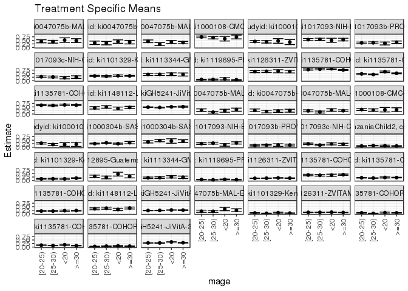

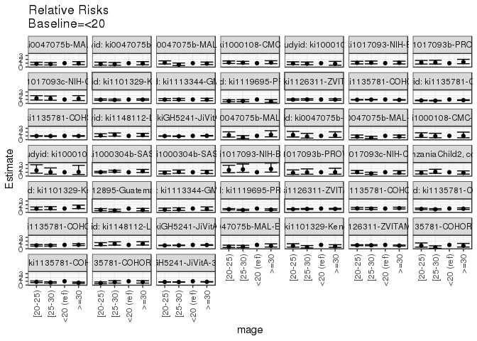

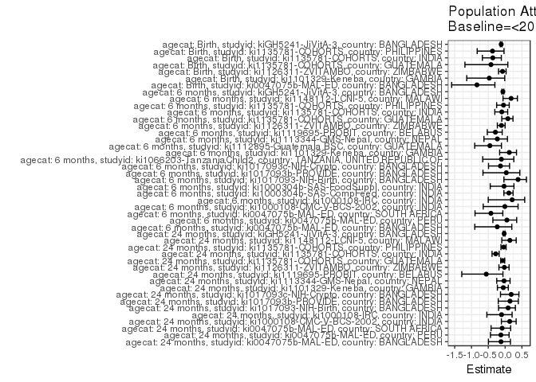

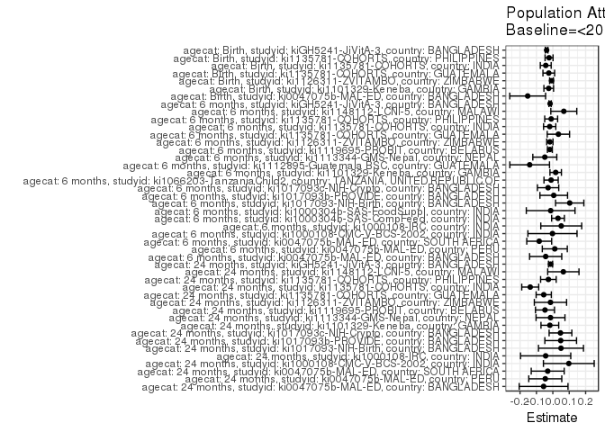

## Results Table

### Parameter: TSM

| agecat | studyid | country | intervention_level | baseline_level | estimate | ci_lower | ci_upper |
| --- | --- | --- | --- | --- | --- | --- | --- |
| Birth | ki0047075b-MAL-ED | BANGLADESH | <20 | NA | 0.3362219 | 0.2161405 | 0.4563033 |
| Birth | ki0047075b-MAL-ED | BANGLADESH | [20-25) | NA | 0.1823927 | 0.1064626 | 0.2583227 |
| Birth | ki0047075b-MAL-ED | BANGLADESH | [25-30) | NA | 0.1753622 | 0.1039149 | 0.2468095 |
| Birth | ki0047075b-MAL-ED | BANGLADESH | >=30 | NA | 0.2505571 | 0.1471371 | 0.3539771 |
| Birth | ki1101329-Keneba | GAMBIA | <20 | NA | 0.0783067 | 0.0456213 | 0.1109921 |
| Birth | ki1101329-Keneba | GAMBIA | [20-25) | NA | 0.0574347 | 0.0338297 | 0.0810397 |
| Birth | ki1101329-Keneba | GAMBIA | [25-30) | NA | 0.0320426 | 0.0135467 | 0.0505386 |
| Birth | ki1101329-Keneba | GAMBIA | >=30 | NA | 0.0477964 | 0.0305495 | 0.0650433 |
| Birth | ki1126311-ZVITAMBO | ZIMBABWE | <20 | NA | 0.1113619 | 0.0985592 | 0.1241647 |
| Birth | ki1126311-ZVITAMBO | ZIMBABWE | [20-25) | NA | 0.1016744 | 0.0939842 | 0.1093645 |
| Birth | ki1126311-ZVITAMBO | ZIMBABWE | [25-30) | NA | 0.1012716 | 0.0913259 | 0.1112174 |
| Birth | ki1126311-ZVITAMBO | ZIMBABWE | >=30 | NA | 0.0915172 | 0.0801231 | 0.1029112 |
| Birth | ki1135781-COHORTS | GUATEMALA | <20 | NA | 0.0833534 | 0.0444650 | 0.1222418 |
| Birth | ki1135781-COHORTS | GUATEMALA | [20-25) | NA | 0.0664705 | 0.0367367 | 0.0962044 |
| Birth | ki1135781-COHORTS | GUATEMALA | [25-30) | NA | 0.0252778 | 0.0051885 | 0.0453671 |
| Birth | ki1135781-COHORTS | GUATEMALA | >=30 | NA | 0.0647216 | 0.0407383 | 0.0887048 |
| Birth | ki1135781-COHORTS | INDIA | <20 | NA | 0.1615792 | 0.1267170 | 0.1964414 |
| Birth | ki1135781-COHORTS | INDIA | [20-25) | NA | 0.1351328 | 0.1187943 | 0.1514713 |
| Birth | ki1135781-COHORTS | INDIA | [25-30) | NA | 0.1084422 | 0.0932299 | 0.1236544 |
| Birth | ki1135781-COHORTS | INDIA | >=30 | NA | 0.0978553 | 0.0812722 | 0.1144385 |
| Birth | ki1135781-COHORTS | PHILIPPINES | <20 | NA | 0.0842991 | 0.0577200 | 0.1108781 |
| Birth | ki1135781-COHORTS | PHILIPPINES | [20-25) | NA | 0.0449703 | 0.0320307 | 0.0579100 |
| Birth | ki1135781-COHORTS | PHILIPPINES | [25-30) | NA | 0.0652337 | 0.0490397 | 0.0814277 |
| Birth | ki1135781-COHORTS | PHILIPPINES | >=30 | NA | 0.0653051 | 0.0492837 | 0.0813265 |
| Birth | kiGH5241-JiVitA-3 | BANGLADESH | <20 | NA | 0.3610147 | 0.3500626 | 0.3719667 |
| Birth | kiGH5241-JiVitA-3 | BANGLADESH | [20-25) | NA | 0.2928246 | 0.2804308 | 0.3052184 |
| Birth | kiGH5241-JiVitA-3 | BANGLADESH | [25-30) | NA | 0.2892061 | 0.2725860 | 0.3058263 |
| Birth | kiGH5241-JiVitA-3 | BANGLADESH | >=30 | NA | 0.3055556 | 0.2842625 | 0.3268488 |
| 6 months | ki0047075b-MAL-ED | BANGLADESH | <20 | NA | 0.2304120 | 0.1246852 | 0.3361387 |
| 6 months | ki0047075b-MAL-ED | BANGLADESH | [20-25) | NA | 0.2731149 | 0.1850953 | 0.3611345 |

[output cut: 150 more lines]

### Parameter: E(Y)

| agecat | studyid | country | intervention_level | baseline_level | estimate | ci_lower | ci_upper |
| --- | --- | --- | --- | --- | --- | --- | --- |
| Birth | ki0047075b-MAL-ED | BANGLADESH | NA | NA | 0.1828794 | 0.1355257 | 0.2302330 |
| Birth | ki1101329-Keneba | GAMBIA | NA | NA | 0.0532122 | 0.0420018 | 0.0644226 |
| Birth | ki1126311-ZVITAMBO | ZIMBABWE | NA | NA | 0.1034083 | 0.0983260 | 0.1084905 |
| Birth | ki1135781-COHORTS | GUATEMALA | NA | NA | 0.0586854 | 0.0428942 | 0.0744767 |
| Birth | ki1135781-COHORTS | INDIA | NA | NA | 0.1183457 | 0.1091247 | 0.1275667 |
| Birth | ki1135781-COHORTS | PHILIPPINES | NA | NA | 0.0613115 | 0.0527962 | 0.0698268 |
| Birth | kiGH5241-JiVitA-3 | BANGLADESH | NA | NA | 0.3231138 | 0.3154608 | 0.3307668 |
| 6 months | ki0047075b-MAL-ED | BANGLADESH | NA | NA | 0.1867220 | 0.1374205 | 0.2360234 |
| 6 months | ki0047075b-MAL-ED | PERU | NA | NA | 0.2197802 | 0.1705687 | 0.2689917 |
| 6 months | ki0047075b-MAL-ED | SOUTH AFRICA | NA | NA | 0.1968504 | 0.1478551 | 0.2458457 |
| 6 months | ki1000108-CMC-V-BCS-2002 | INDIA | NA | NA | 0.3008130 | 0.2539566 | 0.3476694 |
| 6 months | ki1000108-IRC | INDIA | NA | NA | 0.2457002 | 0.2038248 | 0.2875757 |
| 6 months | ki1000304b-SAS-CompFeed | INDIA | NA | NA | 0.2844311 | 0.2666491 | 0.3022132 |
| 6 months | ki1000304b-SAS-FoodSuppl | INDIA | NA | NA | 0.4289474 | 0.3791199 | 0.4787748 |
| 6 months | ki1017093-NIH-Birth | BANGLADESH | NA | NA | 0.2672897 | 0.2297549 | 0.3048246 |
| 6 months | ki1017093b-PROVIDE | BANGLADESH | NA | NA | 0.1612350 | 0.1313580 | 0.1911120 |
| 6 months | ki1017093c-NIH-Crypto | BANGLADESH | NA | NA | 0.2097902 | 0.1799252 | 0.2396552 |
| 6 months | ki1066203-TanzaniaChild2 | TANZANIA, UNITED REPUBLIC OF | NA | NA | 0.0964215 | 0.0835208 | 0.1093221 |
| 6 months | ki1101329-Keneba | GAMBIA | NA | NA | 0.1408654 | 0.1259115 | 0.1558193 |
| 6 months | ki1112895-Guatemala BSC | GUATEMALA | NA | NA | 0.3115942 | 0.2568550 | 0.3663334 |
| 6 months | ki1113344-GMS-Nepal | NEPAL | NA | NA | 0.2113677 | 0.1776128 | 0.2451226 |
| 6 months | ki1119695-PROBIT | BELARUS | NA | NA | 0.0626864 | 0.0488489 | 0.0765239 |
| 6 months | ki1126311-ZVITAMBO | ZIMBABWE | NA | NA | 0.1660628 | 0.1580467 | 0.1740789 |
| 6 months | ki1135781-COHORTS | GUATEMALA | NA | NA | 0.4099896 | 0.3788775 | 0.4411017 |
| 6 months | ki1135781-COHORTS | INDIA | NA | NA | 0.1959625 | 0.1848518 | 0.2070732 |
| 6 months | ki1135781-COHORTS | PHILIPPINES | NA | NA | 0.2112260 | 0.1958496 | 0.2266024 |
| 6 months | ki1148112-LCNI-5 | MALAWI | NA | NA | 0.3736921 | 0.3370052 | 0.4103790 |
| 6 months | kiGH5241-JiVitA-3 | BANGLADESH | NA | NA | 0.2514133 | 0.2432880 | 0.2595385 |
| 24 months | ki0047075b-MAL-ED | BANGLADESH | NA | NA | 0.4622642 | 0.3949918 | 0.5295365 |
| 24 months | ki0047075b-MAL-ED | PERU | NA | NA | 0.3681592 | 0.3013164 | 0.4350020 |
| 24 months | ki0047075b-MAL-ED | SOUTH AFRICA | NA | NA | 0.3529412 | 0.2921001 | 0.4137823 |
| 24 months | ki1000108-CMC-V-BCS-2002 | INDIA | NA | NA | 0.7150538 | 0.6691221 | 0.7609854 |
| 24 months | ki1000108-IRC | INDIA | NA | NA | 0.4156479 | 0.3678270 | 0.4634689 |
| 24 months | ki1017093-NIH-Birth | BANGLADESH | NA | NA | 0.5550351 | 0.5078433 | 0.6022269 |
| 24 months | ki1017093b-PROVIDE | BANGLADESH | NA | NA | 0.3292894 | 0.2909105 | 0.3676684 |
| 24 months | ki1017093c-NIH-Crypto | BANGLADESH | NA | NA | 0.2568093 | 0.2190047 | 0.2946140 |
| 24 months | ki1101329-Keneba | GAMBIA | NA | NA | 0.3348891 | 0.3125397 | 0.3572386 |
| 24 months | ki1113344-GMS-Nepal | NEPAL | NA | NA | 0.4468938 | 0.4032281 | 0.4905594 |
| 24 months | ki1119695-PROBIT | BELARUS | NA | NA | 0.0852540 | 0.0554439 | 0.1150642 |
| 24 months | ki1126311-ZVITAMBO | ZIMBABWE | NA | NA | 0.6535088 | 0.6097853 | 0.6972322 |
| 24 months | ki1135781-COHORTS | GUATEMALA | NA | NA | 0.7919400 | 0.7675726 | 0.8163075 |
| 24 months | ki1135781-COHORTS | INDIA | NA | NA | 0.4944520 | 0.4783291 | 0.5105749 |
| 24 months | ki1135781-COHORTS | PHILIPPINES | NA | NA | 0.6167689 | 0.5974942 | 0.6360437 |
| 24 months | ki1148112-LCNI-5 | MALAWI | NA | NA | 0.4505263 | 0.4057351 | 0.4953175 |
| 24 months | kiGH5241-JiVitA-3 | BANGLADESH | NA | NA | 0.4909007 | 0.4777498 | 0.5040515 |

### Parameter: RR

| agecat | studyid | country | intervention_level | baseline_level | estimate | ci_lower | ci_upper |
| --- | --- | --- | --- | --- | --- | --- | --- |
| Birth | ki0047075b-MAL-ED | BANGLADESH | <20 | <20 | 1.0000000 | 1.0000000 | 1.0000000 |
| Birth | ki0047075b-MAL-ED | BANGLADESH | [20-25) | <20 | 0.5424770 | 0.3137223 | 0.9380312 |
| Birth | ki0047075b-MAL-ED | BANGLADESH | [25-30) | <20 | 0.5215668 | 0.3039276 | 0.8950553 |
| Birth | ki0047075b-MAL-ED | BANGLADESH | >=30 | <20 | 0.7452135 | 0.4321094 | 1.2851911 |
| Birth | ki1101329-Keneba | GAMBIA | <20 | <20 | 1.0000000 | 1.0000000 | 1.0000000 |
| Birth | ki1101329-Keneba | GAMBIA | [20-25) | <20 | 0.7334579 | 0.4083599 | 1.3173687 |
| Birth | ki1101329-Keneba | GAMBIA | [25-30) | <20 | 0.4091939 | 0.2007253 | 0.8341729 |
| Birth | ki1101329-Keneba | GAMBIA | >=30 | <20 | 0.6103744 | 0.3516181 | 1.0595498 |
| Birth | ki1126311-ZVITAMBO | ZIMBABWE | <20 | <20 | 1.0000000 | 1.0000000 | 1.0000000 |
| Birth | ki1126311-ZVITAMBO | ZIMBABWE | [20-25) | <20 | 0.9130083 | 0.7957479 | 1.0475482 |
| Birth | ki1126311-ZVITAMBO | ZIMBABWE | [25-30) | <20 | 0.9093919 | 0.7818822 | 1.0576959 |
| Birth | ki1126311-ZVITAMBO | ZIMBABWE | >=30 | <20 | 0.8217993 | 0.6937852 | 0.9734341 |
| Birth | ki1135781-COHORTS | GUATEMALA | <20 | <20 | 1.0000000 | 1.0000000 | 1.0000000 |
| Birth | ki1135781-COHORTS | GUATEMALA | [20-25) | <20 | 0.7974545 | 0.4195788 | 1.5156481 |
| Birth | ki1135781-COHORTS | GUATEMALA | [25-30) | <20 | 0.3032606 | 0.1209561 | 0.7603334 |
| Birth | ki1135781-COHORTS | GUATEMALA | >=30 | <20 | 0.7764719 | 0.4299970 | 1.4021230 |
| Birth | ki1135781-COHORTS | INDIA | <20 | <20 | 1.0000000 | 1.0000000 | 1.0000000 |
| Birth | ki1135781-COHORTS | INDIA | [20-25) | <20 | 0.8363258 | 0.6531180 | 1.0709257 |
| Birth | ki1135781-COHORTS | INDIA | [25-30) | <20 | 0.6711395 | 0.5189081 | 0.8680307 |
| Birth | ki1135781-COHORTS | INDIA | >=30 | <20 | 0.6056185 | 0.4603522 | 0.7967241 |
| Birth | ki1135781-COHORTS | PHILIPPINES | <20 | <20 | 1.0000000 | 1.0000000 | 1.0000000 |
| Birth | ki1135781-COHORTS | PHILIPPINES | [20-25) | <20 | 0.5334618 | 0.3483380 | 0.8169695 |
| Birth | ki1135781-COHORTS | PHILIPPINES | [25-30) | <20 | 0.7738360 | 0.5184820 | 1.1549527 |
| Birth | ki1135781-COHORTS | PHILIPPINES | >=30 | <20 | 0.7746834 | 0.5200518 | 1.1539895 |
| Birth | kiGH5241-JiVitA-3 | BANGLADESH | <20 | <20 | 1.0000000 | 1.0000000 | 1.0000000 |
| Birth | kiGH5241-JiVitA-3 | BANGLADESH | [20-25) | <20 | 0.8111155 | 0.7717935 | 0.8524409 |
| Birth | kiGH5241-JiVitA-3 | BANGLADESH | [25-30) | <20 | 0.8010925 | 0.7524249 | 0.8529080 |
| Birth | kiGH5241-JiVitA-3 | BANGLADESH | >=30 | <20 | 0.8463801 | 0.7853614 | 0.9121398 |
| 6 months | ki0047075b-MAL-ED | BANGLADESH | <20 | <20 | 1.0000000 | 1.0000000 | 1.0000000 |
| 6 months | ki0047075b-MAL-ED | BANGLADESH | [20-25) | <20 | 1.1853329 | 0.6801465 | 2.0657522 |

[output cut: 150 more lines]

### Parameter: PAR

| agecat | studyid | country | intervention_level | baseline_level | estimate | ci_lower | ci_upper |
| --- | --- | --- | --- | --- | --- | --- | --- |
| Birth | ki0047075b-MAL-ED | BANGLADESH | <20 | NA | -0.1533425 | -0.2626053 | -0.0440797 |
| Birth | ki1101329-Keneba | GAMBIA | <20 | NA | -0.0250945 | -0.0546002 | 0.0044111 |
| Birth | ki1126311-ZVITAMBO | ZIMBABWE | <20 | NA | -0.0079537 | -0.0195899 | 0.0036826 |
| Birth | ki1135781-COHORTS | GUATEMALA | <20 | NA | -0.0246680 | -0.0603093 | 0.0109734 |
| Birth | ki1135781-COHORTS | INDIA | <20 | NA | -0.0432335 | -0.0763657 | -0.0101013 |
| Birth | ki1135781-COHORTS | PHILIPPINES | <20 | NA | -0.0229876 | -0.0472574 | 0.0012822 |
| Birth | kiGH5241-JiVitA-3 | BANGLADESH | <20 | NA | -0.0379009 | -0.0457745 | -0.0300273 |
| 6 months | ki0047075b-MAL-ED | BANGLADESH | <20 | NA | -0.0436900 | -0.1417447 | 0.0543648 |
| 6 months | ki0047075b-MAL-ED | PERU | <20 | NA | 0.0119452 | -0.0642639 | 0.0881544 |
| 6 months | ki0047075b-MAL-ED | SOUTH AFRICA | <20 | NA | -0.0831544 | -0.1590557 | -0.0072531 |
| 6 months | ki1000108-CMC-V-BCS-2002 | INDIA | <20 | NA | -0.0022173 | -0.1520126 | 0.1475780 |
| 6 months | ki1000108-IRC | INDIA | <20 | NA | 0.0512558 | -0.0734230 | 0.1759346 |
| 6 months | ki1000304b-SAS-CompFeed | INDIA | <20 | NA | 0.0315164 | -0.0074247 | 0.0704576 |
| 6 months | ki1000304b-SAS-FoodSuppl | INDIA | <20 | NA | -0.0132876 | -0.1618493 | 0.1352741 |
| 6 months | ki1017093-NIH-Birth | BANGLADESH | <20 | NA | 0.1028621 | 0.0165729 | 0.1891512 |
| 6 months | ki1017093b-PROVIDE | BANGLADESH | <20 | NA | 0.0055710 | -0.0786828 | 0.0898249 |
| 6 months | ki1017093c-NIH-Crypto | BANGLADESH | <20 | NA | -0.0289226 | -0.0939215 | 0.0360764 |
| 6 months | ki1066203-TanzaniaChild2 | TANZANIA, UNITED REPUBLIC OF | <20 | NA | -0.0106838 | -0.0540629 | 0.0326952 |
| 6 months | ki1101329-Keneba | GAMBIA | <20 | NA | 0.0174168 | -0.0175306 | 0.0523643 |
| 6 months | ki1112895-Guatemala BSC | GUATEMALA | <20 | NA | -0.1411851 | -0.2621217 | -0.0202486 |
| 6 months | ki1113344-GMS-Nepal | NEPAL | <20 | NA | -0.0489202 | -0.1220029 | 0.0241626 |
| 6 months | ki1119695-PROBIT | BELARUS | <20 | NA | -0.0181219 | -0.0330334 | -0.0032103 |
| 6 months | ki1126311-ZVITAMBO | ZIMBABWE | <20 | NA | -0.0181670 | -0.0373061 | 0.0009722 |
| 6 months | ki1135781-COHORTS | GUATEMALA | <20 | NA | 0.0338748 | -0.0343178 | 0.1020674 |
| 6 months | ki1135781-COHORTS | INDIA | <20 | NA | -0.0192480 | -0.0565562 | 0.0180602 |
| 6 months | ki1135781-COHORTS | PHILIPPINES | <20 | NA | -0.0101365 | -0.0494871 | 0.0292140 |
| 6 months | ki1148112-LCNI-5 | MALAWI | <20 | NA | 0.0669284 | -0.0122011 | 0.1460578 |
| 6 months | kiGH5241-JiVitA-3 | BANGLADESH | <20 | NA | -0.0167552 | -0.0236479 | -0.0098624 |
| 24 months | ki0047075b-MAL-ED | BANGLADESH | <20 | NA | -0.0563900 | -0.2051968 | 0.0924167 |
| 24 months | ki0047075b-MAL-ED | PERU | <20 | NA | -0.0460487 | -0.1466711 | 0.0545737 |
| 24 months | ki0047075b-MAL-ED | SOUTH AFRICA | <20 | NA | -0.0312712 | -0.1318052 | 0.0692628 |
| 24 months | ki1000108-CMC-V-BCS-2002 | INDIA | <20 | NA | 0.0974067 | -0.0574265 | 0.2522399 |
| 24 months | ki1000108-IRC | INDIA | <20 | NA | -0.0438115 | -0.1969732 | 0.1093501 |
| 24 months | ki1017093-NIH-Birth | BANGLADESH | <20 | NA | 0.0496830 | -0.0874799 | 0.1868459 |
| 24 months | ki1017093b-PROVIDE | BANGLADESH | <20 | NA | 0.0479293 | -0.0486635 | 0.1445222 |
| 24 months | ki1017093c-NIH-Crypto | BANGLADESH | <20 | NA | 0.0465852 | -0.0225927 | 0.1157630 |
| 24 months | ki1101329-Keneba | GAMBIA | <20 | NA | -0.0182108 | -0.0722822 | 0.0358607 |
| 24 months | ki1113344-GMS-Nepal | NEPAL | <20 | NA | -0.0142347 | -0.1023849 | 0.0739155 |
| 24 months | ki1119695-PROBIT | BELARUS | <20 | NA | -0.0478312 | -0.1058393 | 0.0101768 |
| 24 months | ki1126311-ZVITAMBO | ZIMBABWE | <20 | NA | -0.0144726 | -0.1128286 | 0.0838834 |
| 24 months | ki1135781-COHORTS | GUATEMALA | <20 | NA | -0.0554888 | -0.1018999 | -0.0090777 |
| 24 months | ki1135781-COHORTS | INDIA | <20 | NA | -0.1378762 | -0.1895377 | -0.0862147 |
| 24 months | ki1135781-COHORTS | PHILIPPINES | <20 | NA | -0.0270259 | -0.0744597 | 0.0204078 |
| 24 months | ki1148112-LCNI-5 | MALAWI | <20 | NA | 0.0640838 | -0.0313231 | 0.1594907 |
| 24 months | kiGH5241-JiVitA-3 | BANGLADESH | <20 | NA | -0.0138841 | -0.0264238 | -0.0013445 |

### Parameter: PAF

| agecat | studyid | country | intervention_level | baseline_level | estimate | ci_lower | ci_upper |
| --- | --- | --- | --- | --- | --- | --- | --- |
| Birth | ki0047075b-MAL-ED | BANGLADESH | <20 | NA | -0.8384900 | -1.5912436 | -0.3044106 |
| Birth | ki1101329-Keneba | GAMBIA | <20 | NA | -0.4715938 | -1.1421963 | -0.0109196 |
| Birth | ki1126311-ZVITAMBO | ZIMBABWE | <20 | NA | -0.0769153 | -0.1955073 | 0.0299126 |
| Birth | ki1135781-COHORTS | GUATEMALA | <20 | NA | -0.4203419 | -1.1953778 | 0.0810825 |
| Birth | ki1135781-COHORTS | INDIA | <20 | NA | -0.3653151 | -0.6759583 | -0.1122504 |
| Birth | ki1135781-COHORTS | PHILIPPINES | <20 | NA | -0.3749315 | -0.8306586 | -0.0326539 |
| Birth | kiGH5241-JiVitA-3 | BANGLADESH | <20 | NA | -0.1172988 | -0.1421101 | -0.0930265 |
| 6 months | ki0047075b-MAL-ED | BANGLADESH | <20 | NA | -0.2339841 | -0.9025263 | 0.1996344 |
| 6 months | ki0047075b-MAL-ED | PERU | <20 | NA | 0.0543508 | -0.3643308 | 0.3445486 |
| 6 months | ki0047075b-MAL-ED | SOUTH AFRICA | <20 | NA | -0.4224243 | -0.8953002 | -0.0675305 |
| 6 months | ki1000108-CMC-V-BCS-2002 | INDIA | <20 | NA | -0.0073710 | -0.6514740 | 0.3855208 |
| 6 months | ki1000108-IRC | INDIA | <20 | NA | 0.2086111 | -0.5015179 | 0.5828912 |
| 6 months | ki1000304b-SAS-CompFeed | INDIA | <20 | NA | 0.1108052 | -0.0367816 | 0.2373829 |
| 6 months | ki1000304b-SAS-FoodSuppl | INDIA | <20 | NA | -0.0309772 | -0.4425556 | 0.2631729 |
| 6 months | ki1017093-NIH-Birth | BANGLADESH | <20 | NA | 0.3848336 | -0.0354863 | 0.6345392 |
| 6 months | ki1017093b-PROVIDE | BANGLADESH | <20 | NA | 0.0345523 | -0.6593838 | 0.4382920 |
| 6 months | ki1017093c-NIH-Crypto | BANGLADESH | <20 | NA | -0.1378642 | -0.4935746 | 0.1331300 |
| 6 months | ki1066203-TanzaniaChild2 | TANZANIA, UNITED REPUBLIC OF | <20 | NA | -0.1108035 | -0.6661885 | 0.2594569 |
| 6 months | ki1101329-Keneba | GAMBIA | <20 | NA | 0.1236416 | -0.1622006 | 0.3391812 |
| 6 months | ki1112895-Guatemala BSC | GUATEMALA | <20 | NA | -0.4531058 | -0.9041490 | -0.1089029 |
| 6 months | ki1113344-GMS-Nepal | NEPAL | <20 | NA | -0.2314459 | -0.6298527 | 0.0695730 |
| 6 months | ki1119695-PROBIT | BELARUS | <20 | NA | -0.2890876 | -0.5300449 | -0.0860772 |
| 6 months | ki1126311-ZVITAMBO | ZIMBABWE | <20 | NA | -0.1093981 | -0.2307698 | 0.0000046 |
| 6 months | ki1135781-COHORTS | GUATEMALA | <20 | NA | 0.0826237 | -0.0992176 | 0.2343833 |
| 6 months | ki1135781-COHORTS | INDIA | <20 | NA | -0.0982227 | -0.3061874 | 0.0766308 |
| 6 months | ki1135781-COHORTS | PHILIPPINES | <20 | NA | -0.0479891 | -0.2519140 | 0.1227184 |
| 6 months | ki1148112-LCNI-5 | MALAWI | <20 | NA | 0.1791003 | -0.0623505 | 0.3656742 |
| 6 months | kiGH5241-JiVitA-3 | BANGLADESH | <20 | NA | -0.0666439 | -0.0943907 | -0.0396007 |
| 24 months | ki0047075b-MAL-ED | BANGLADESH | <20 | NA | -0.1219866 | -0.4957680 | 0.1583895 |
| 24 months | ki0047075b-MAL-ED | PERU | <20 | NA | -0.1250782 | -0.4357032 | 0.1183408 |
| 24 months | ki0047075b-MAL-ED | SOUTH AFRICA | <20 | NA | -0.0886018 | -0.4181031 | 0.1643388 |
| 24 months | ki1000108-CMC-V-BCS-2002 | INDIA | <20 | NA | 0.1362229 | -0.1106257 | 0.3282067 |
| 24 months | ki1000108-IRC | INDIA | <20 | NA | -0.1054054 | -0.5429054 | 0.2080389 |
| 24 months | ki1017093-NIH-Birth | BANGLADESH | <20 | NA | 0.0895132 | -0.1947177 | 0.3061238 |
| 24 months | ki1017093b-PROVIDE | BANGLADESH | <20 | NA | 0.1455538 | -0.2040542 | 0.3936500 |
| 24 months | ki1017093c-NIH-Crypto | BANGLADESH | <20 | NA | 0.1813999 | -0.1368520 | 0.4105599 |
| 24 months | ki1101329-Keneba | GAMBIA | <20 | NA | -0.0543784 | -0.2290573 | 0.0954743 |
| 24 months | ki1113344-GMS-Nepal | NEPAL | <20 | NA | -0.0318524 | -0.2492456 | 0.1477100 |
| 24 months | ki1119695-PROBIT | BELARUS | <20 | NA | -0.5610437 | -1.2891899 | -0.0645065 |
| 24 months | ki1126311-ZVITAMBO | ZIMBABWE | <20 | NA | -0.0221460 | -0.1843003 | 0.1178062 |
| 24 months | ki1135781-COHORTS | GUATEMALA | <20 | NA | -0.0700670 | -0.1306847 | -0.0126991 |
| 24 months | ki1135781-COHORTS | INDIA | <20 | NA | -0.2788465 | -0.3886811 | -0.1776991 |
| 24 months | ki1135781-COHORTS | PHILIPPINES | <20 | NA | -0.0438186 | -0.1237099 | 0.0303927 |
| 24 months | ki1148112-LCNI-5 | MALAWI | <20 | NA | 0.1422421 | -0.0981904 | 0.3300354 |
| 24 months | kiGH5241-JiVitA-3 | BANGLADESH | <20 | NA | -0.0282830 | -0.0541607 | -0.0030405 |